# LTER: SiSyn

Updated 2021-08-11 14:10:56

## Objective

1. Develop a function to evaluate C-Q relationships that includes several different modeling approaches.

**Models:**

- Log-Linear (power law): $C=\alpha Q^{\beta}$ or the linearized version of $log(C) = \beta log(\alpha) + log(Q)$.
- Segmented: (with one break point)

$log(C) = \beta_{1} log(\alpha_1) + log(Q)$ for Q < Break point

$log(C) = \beta_{2} log(\alpha_2) + log(Q)$ for Q > Break point

Breakpoints are determined through an iterative process and identified when the linear relationship changes. The model is estimated simultaneously yielding point estimates and relevant approximate standard errors of all the model parameters, including the break-points.

- *“Moatar”*: Similar to segmented regression with a pre-defined breakpoint. Based on analyses presented by [Moatar et al. (2017)](https://agupubs.onlinelibrary.wiley.com/doi/10.1002/2016WR019635). Individual slopes were estimated for discharges below and above the median daily discharge ($\beta_{50inf}$ and $\beta_{50sup}$, respectively where *“inf”* = inferior (below) and *“sup”* = superior (above)). The predicted concentrations for both models were averaged.

## Function

```r
# To check and install if needed packages
check.packages <- function(pkg){
  new.pkg <- pkg[!(pkg %in% installed.packages()[, "Package"])]
  if (length(new.pkg))
    install.packages(new.pkg, dependencies = TRUE)
  sapply(pkg, require, character.only = TRUE)
}

pkg=c("segmented","gvlma")
check.packages(pkg)
```

```r
library(segmented)
library(gvlma)
#' Fitting models to Concentration-Discharge data using several different
#' models/methods and extracting relevat information

#' @param logQ       log transformed paired discharge value
#' @param logC       log transformed paired concentration value
#' @param Q50        median value of daily discharge
#' @param plot       default = TRUE; identifies if you want to plot results.
#' @param models     default = c("log-linear","segmented","moatar"); identified
#'                   what models to plot
#' @param plot.CI    default = TRUE; If the models are plotted a 95% confidence
#'                   interval will also be plotted
#' @param CI.level   default = 0.95; confidence interval level
#' @param plot.lwd   default = 1.5; model line thickness
#' @param legend.pos default = "topleft"; legend position if models are plotted
#' @param print.rslt defualt = TRUE; print output table.
#' @param ...        other plotting variables see ?plot (i.e. pch, lwd, bg, col, ylim, etc.)

CQ_fun=function(logQ,logC,Q50,plot=TRUE,
                models=c("log-linear","segmented","moatar"),
                plot.CI=TRUE,
                CI.level=0.95,
                plot.lwd=1.5,
                legend.pos="topleft",
                print.rslt=TRUE,
                xlab="Discharge",
                ylab="Concentration",...){

  # Power Law
  loglog.mod=lm(logC~logQ)
  loglog.mod.sum=summary(loglog.mod)

  # Check assumptions
  LL.assump=gvlma(loglog.mod)
  asumpt.rslt=as.character(ifelse(LL.assump$GlobalTest$GlobalStat4$pvalue<0.05,"No","Yes"))

  # variabled of interest
  loglog.beta=as.numeric(coef(loglog.mod)[2])
  loglog.alpha=as.numeric(coef(loglog.mod)[1])

  LL.rslt=data.frame(LL.R2=loglog.mod.sum$r.squared,
                     LL.R2.adj=loglog.mod.sum$adj.r.squared,
                     LL.RMSE=loglog.mod.sum$sigma,
                     LL.beta=loglog.beta,
                     LL.beta.SE=loglog.mod.sum$coefficients[2,2],
                     LL.beta.tval=loglog.mod.sum$coefficients[2,3],
                     LL.beta.pval=loglog.mod.sum$coefficients[2,4],
                     LL.alpha=loglog.alpha,
                     LL.AIC=AIC(loglog.mod),
                     LL.BIC=BIC(loglog.mod),
                     LL.LogLik=as.numeric(logLik(loglog.mod)),
                     LL.assumpt.pass=asumpt.rslt)

  # Segmented
  # Picks 1st breakpoint
  loglog.mod.seg=segmented(loglog.mod,seg.Z=~logQ,npsi=1)
  loglog.mod.seg.sum=summary(loglog.mod.seg)

  # is there a breakpoint?
  if(is.null(loglog.mod.seg$psi)){
    seg.rslt=data.frame(seg.bk.est=NA,
                        seg.bk.SE=NA,
                        seg.R2=NA,
                        seg.R2.adj=NA,
                        seg.RMSE=NA,
                        seg.AIC=NA,
                        seg.BIC=NA,
                        seg.LogLik=NA)
  }else{
    seg.psi.est=loglog.mod.seg$psi[1,c(2)]
    seg.psi.SE=seg.psi=loglog.mod.seg$psi[1,c(3)]
    seg.rslt=data.frame(seg.bk.est=exp(seg.psi.est),
                        seg.bk.SE=exp(seg.psi.SE),
                        seg.R2=loglog.mod.seg.sum$r.squared,
                        seg.R2.adj=loglog.mod.seg.sum$adj.r.squared,
                        seg.RMSE=loglog.mod.seg.sum$sigma,
                        seg.AIC=AIC(loglog.mod.seg),
                        seg.BIC=BIC(loglog.mod.seg),
                        seg.LogLik=as.numeric(logLik(loglog.mod.seg)))
  }



  # Moatar
  logQ.m=logQ[logQ<log(Q50)]
  logC.m=logC[logQ<log(Q50)]
  loglog.mod.inf=lm(logC.m~logQ.m)
  loglog.mod.inf.sum=summary(loglog.mod.inf)
  CQ50.inf=predict(loglog.mod.inf,data.frame(logQ.m=log(Q50)))

  logQ.m=logQ[logQ>log(Q50)]
  logC.m=logC[logQ>log(Q50)]
  loglog.mod.sup=lm(logC.m~logQ.m)
  loglog.mod.sup.sum=summary(loglog.mod.sup)
  CQ50.sup=predict(loglog.mod.sup,data.frame(logQ.m=log(Q50)))

  moatar.rslt=data.frame(Q50=Q50,
                         moatar.beta.inf=as.numeric(coef(loglog.mod.inf)[2]),
                         moatar.R2.inf=loglog.mod.inf.sum$r.squared,
                         moatar.R2.adj.inf=loglog.mod.inf.sum$adj.r.squared,
                         moatar.RMSE.inf=loglog.mod.inf.sum$sigma,
                         moatar.beta.sup=as.numeric(coef(loglog.mod.sup)[2]),
                         moatar.R2.sup=loglog.mod.sup.sum$r.squared,
                         moatar.R2.adj.sup=loglog.mod.sup.sum$adj.r.squared,
                         moatar.RMSE.sup=loglog.mod.sup.sum$sigma,
                         moatar.C_Q50=exp(mean(c(CQ50.inf,CQ50.sup))))

  rslt.all=cbind(LL.rslt,seg.rslt,moatar.rslt)

  # Plotting
  c.val=exp(logC)
  q.val=exp(logQ)
  if(plot==T){
    plot(c.val~q.val,log="xy",...)

    if(sum(match(models,"log-linear"),na.rm=T)==1){
      x.val=seq(min(logQ,na.rm=T),max(logQ,na.rm=T),length.out=70)
      LL.pred=predict(loglog.mod,data.frame(logQ=x.val),interval="confidence",
                      level=CI.level)
      lines(exp(x.val),exp(LL.pred[,1]),col="red",lwd=plot.lwd)
      if(plot.CI==T){
        lines(exp(x.val),exp(LL.pred[,2]),col="red",lty=2)
        lines(exp(x.val),exp(LL.pred[,3]),col="red",lty=2)
      }
    }

    if(is.null(loglog.mod.seg$psi)==F){
    if(sum(match(models,"segmented"),na.rm=T)==1){
      x.val=seq(min(logQ,na.rm=T),max(logQ,na.rm=T),length.out=70)
      seg.pred=predict(loglog.mod.seg,data.frame(logQ=x.val),
                       interval="confidence",level=CI.level)
      lines(exp(x.val),exp(seg.pred[,1]),col="blue",lwd=plot.lwd)
      if(plot.CI==T){
        lines(exp(x.val),exp(seg.pred[,2]),col="blue",lty=2)
        lines(exp(x.val),exp(seg.pred[,3]),col="blue",lty=2)
      }
    }
    }

    if(sum(match(models,"moatar"),na.rm=T)==1){
      abline(v=Q50)
      x.val=seq(min(logQ,na.rm=T),log(Q50),length.out=50)
      LL.inf=predict(loglog.mod.inf,data.frame(logQ.m=x.val),
                     interval="confidence",level=CI.level)
      lines(exp(x.val),exp(LL.inf[,1]),col="forestgreen",lwd=plot.lwd)
      if(plot.CI==T){
        lines(exp(x.val),exp(LL.inf[,2]),col="forestgreen",lty=2)
        lines(exp(x.val),exp(LL.inf[,3]),col="forestgreen",lty=2)
      }

      x.val=seq(log(Q50),max(logQ,na.rm=T),length.out=50)
      LL.sup=predict(loglog.mod.sup,data.frame(logQ.m=x.val),
                     interval="confidence",level=CI.level)
      lines(exp(x.val),exp(LL.sup[,1]),col="forestgreen")
      if(plot.CI==T){
        lines(exp(x.val),exp(LL.sup[,2]),col="forestgreen",lty=2)
        lines(exp(x.val),exp(LL.sup[,3]),col="forestgreen",lty=2)
      }
    }

    mod.col=c("red","blue","forestgreen")
    mod.col=mod.col[match(models,c("log-linear","segmented","moatar"))]
    legend.pos=if(is.na(legend.pos)==T){"topleft"}else(legend.pos)
    legend(legend.pos,
           legend=models,
           lty=1,
           col=mod.col,
           ncol=1,bty="n",y.intersp=1,x.intersp=0.75,
           xpd=NA,xjust=0.5,yjust=0.5,title="Model",title.adj = 0)

  }
  if(print.rslt==TRUE){return(rslt.all)}
}
```

Output includes measure of relative and absolute fit, slopes and intercepts and breakpoints as a `data.frame`.

- `LL.R2` : Log-linear R<sup>2</sup>
- `LL.R2.adj` : Log-linear adjusted R<sup>2</sup>
- `LL.RMSE` : Log-linear Root Mean Square Error
- `LL.beta` : Log-linear slope
- `LL.beta.SE`: Log-linear slope standard error
- `LL.beta.tval` : Log-linear slope t-value (different from zero)
- `LL.beta.pval` : Log-linear slope p-value (different from zero)
- `LL.alpha` : Log-linear intercept
- `LL.AIC`: Log-Linear AIC
- `LL.BIC`: Log-Linear BIC
- `LL.LogLik`: Log-Linear log-likelihood (used to calculate AIC and BIC)
- `LL.assumpt.pass`: uses `gvlma` package to test linear model assumptions, extracts global test decision.
- `seg.bk.est` : Segmented regression break point (if one is detected). Only reports first break point if more than one is detected (back-transformed)
- `seg.bk.SE` : Segmented regression break point standard error (back-transformed)
- `seg.R2` : Segmented R<sup>2</sup>
- `seg.R2.adj` : Segmented adjusted R<sup>2</sup>
- `seg.RMSE` : Segmented Root Mean Square Error
- `seg.AIC`: Segmented AIC
- `seg.BIC`: Segmented BIC
- `seg.LogLik`: Segmented log-likelihood (used to calculate AIC and BIC)
- `Q50` : Median discharge value used in function input
- `moatar.beta.inf` : Slope of C-Q below the median discharge value
- `moatar.R2.inf` : R<sup>2</sup> of C-Q below the median discharge value
- `moatar.R2.adj.inf` : Adjusted R<sup>2</sup> of C-Q below the median discharge value
- `moatar.RMSE.inf` : Root Mean Square Error of C-Q below the median discharge value
- `moatar.beta.sup` : Slope of C-Q above the median discharge value
- `moatar.R2.sup` : R<sup>2</sup> of C-Q above the median discharge value
- `moatar.R2.adj.sup` : Adjusted R<sup>2</sup> of C-Q above the median discharge value
- `moatar.RMSE.sup` : Root Mean Square Error of C-Q above the median discharge value
- `moatar.C_Q50` : Averaged predicted concentration at median discharge

## Examples

### UMR: M786.2

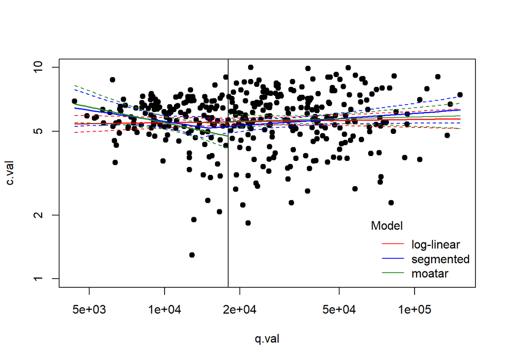

C-Q relationship of M786.2 (UMR; all data) and all models

```
##          LL.R2    LL.R2.adj   LL.RMSE    LL.beta LL.beta.SE LL.beta.tval
## 1 0.0009164036 -0.001813333 0.3739276 0.01538679 0.02655615     0.579406
##   LL.beta.pval LL.alpha   LL.AIC   LL.BIC LL.LogLik LL.assumpt.pass seg.bk.est
## 1    0.5626717 1.560551 324.3351 336.0594 -159.1676              No   14900.55
##   seg.bk.SE     seg.R2 seg.R2.adj  seg.RMSE  seg.AIC seg.BIC seg.LogLik   Q50
## 1  1.334313 0.01539102 0.00727611 0.3722274 322.9646 342.505  -156.4823 18000
##   moatar.beta.inf moatar.R2.inf moatar.R2.adj.inf moatar.RMSE.inf
## 1      -0.2480301    0.03492981        0.02831974       0.4274229
##   moatar.beta.sup moatar.R2.sup moatar.R2.adj.sup moatar.RMSE.sup moatar.C_Q50
## 1      0.02826071     0.0017157      -0.002884689       0.3277656     5.130173
```

```r
# read discharge data
dat.Q=read.csv("./Data/M786.2C_Q_WRTDS.csv")
dat.Q$Date=as.Date(dat.Q$Date)# identify date

# read concentration data
dat.C=read.csv("./Data/M786.2C_Si_WRTDS.csv")
dat.C$Date=as.Date(dat.C$Date)# identify date

# merge the C and Q data
dat.CQ=merge(dat.Q,dat.C,"Date")

Q50=median(dat.Q$Q,na.rm=T)
CQ_fun(log(dat.CQ$Q),log(dat.CQ$Si),Q50,plot.CI=T,pch=19,ylim=c(1,10),
       legend.pos = "bottomright",
       ylab="Si Concentration (mg/L)",
       xlab="Discharge (cfs)")
```

Here is an example of plotting each individual model without individual data points, and output suppressed.

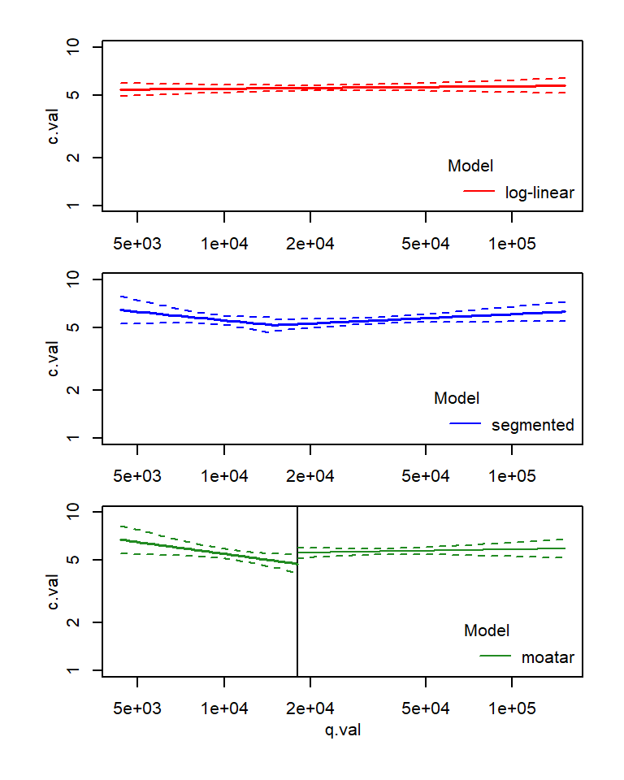

C-Q relationship of M786.2 (UMR; all data) and all models with individual data points removed from the plot

```r
par(mar=c(2,4,1,1),oma=c(3,1,1,1),mgp=c(2,1,0))
layout(matrix(1:3,3,1))
CQ_fun(log(dat.CQ$Q),log(dat.CQ$Si),Q50,plot.CI=T,ylim=c(1,10),
       legend.pos = "bottomright",
       ylab="Si Concentration (mg/L)",
       xlab="Discharge (cfs)",
       type="n",
       models="log-linear",
       print.rslt=F)
CQ_fun(log(dat.CQ$Q),log(dat.CQ$Si),Q50,plot.CI=T,ylim=c(1,10),
       legend.pos = "bottomright",
       ylab="Si Concentration (mg/L)",
       xlab="Discharge (cfs)",
       type="n",
       models="segmented",
       print.rslt=F)
CQ_fun(log(dat.CQ$Q),log(dat.CQ$Si),Q50,plot.CI=T,ylim=c(1,10),
       legend.pos = "bottomright",
       ylab="Si Concentration (mg/L)",
       xlab="Discharge (cfs)",
       type="n",
       models="moatar",
       print.rslt=F,
       xpd=NA)
```

### LUQ: MPR

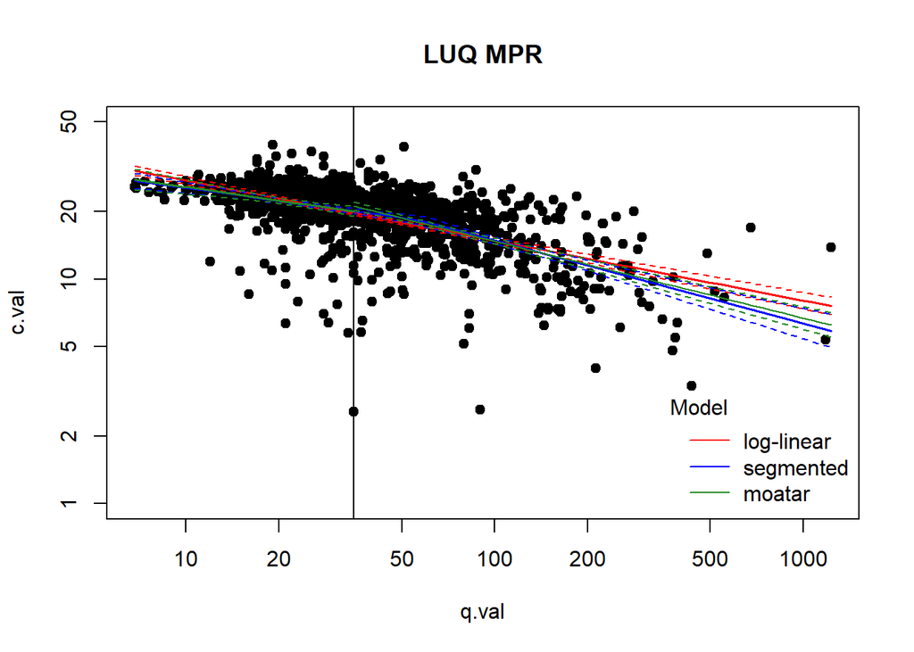

C-Q relationship of MPR (LUQ; all data) and all models

```
##       LL.R2 LL.R2.adj   LL.RMSE    LL.beta LL.beta.SE LL.beta.tval LL.beta.pval
## 1 0.2607266 0.2601216 0.3397364 -0.2674487 0.01288294    -20.75992 3.084079e-82
##   LL.alpha   LL.AIC  LL.BIC LL.LogLik LL.assumpt.pass seg.bk.est seg.bk.SE
## 1 3.928898 834.7354 850.065 -414.3677              No   56.92265  1.222207
##      seg.R2 seg.R2.adj  seg.RMSE  seg.AIC  seg.BIC seg.LogLik Q50
## 1 0.2709456  0.2691529 0.3376566 821.6979 847.2473   -405.849  35
##   moatar.beta.inf moatar.R2.inf moatar.R2.adj.inf moatar.RMSE.inf
## 1      -0.2005908    0.03263879        0.03102652       0.3482593
##   moatar.beta.sup moatar.R2.sup moatar.R2.adj.sup moatar.RMSE.sup moatar.C_Q50
## 1      -0.3427692     0.2892829         0.2881159       0.3179681     20.55023
```

```r
# read discharge data
dat.Q=read.csv("./Data/MPR_Q_WRTDS.csv")
dat.Q$Date=as.Date(dat.Q$Date)# identify date

# read concentration data
dat.C=read.csv("./Data/MPR_Si_WRTDS.csv")
dat.C$Date=as.Date(dat.C$Date)# identify date

# merge the C and Q data
dat.CQ=merge(dat.Q,dat.C,"Date")

Q50=median(dat.Q$Q,na.rm=T)
CQ_fun(log(dat.CQ$Q),log(dat.CQ$Si),Q50,plot.CI=T,pch=19,ylim=c(1,50),
       legend.pos = "bottomright",
       ylab="Si Concentration (mg/L)",
       xlab="Discharge (cfs)",
       main="LUQ MPR")
```

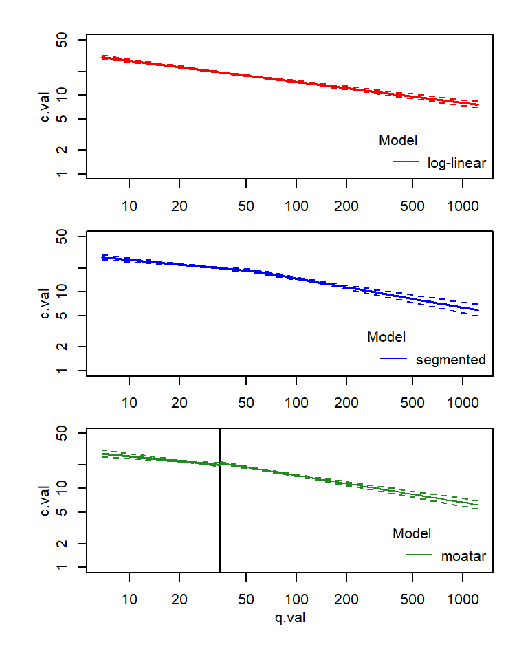

C-Q relationship of MPR (LUQ; all data) and all models with individual data points removed from the plot

```r
par(mar=c(2,4,1,1),oma=c(3,1,1,1),mgp=c(2,1,0))
layout(matrix(1:3,3,1))
CQ_fun(log(dat.CQ$Q),log(dat.CQ$Si),Q50,plot.CI=T,ylim=c(1,50),
       legend.pos = "bottomright",
       ylab="Si Concentration (mg/L)",
       xlab="Discharge (cfs)",
       type="n",
       models="log-linear",
       print.rslt=F)
CQ_fun(log(dat.CQ$Q),log(dat.CQ$Si),Q50,plot.CI=T,ylim=c(1,50),
       legend.pos = "bottomright",
       ylab="Si Concentration (mg/L)",
       xlab="Discharge (cfs)",
       type="n",
       models="segmented",
       print.rslt=F)
CQ_fun(log(dat.CQ$Q),log(dat.CQ$Si),Q50,plot.CI=T,ylim=c(1,50),
       legend.pos = "bottomright",
       ylab="Si Concentration (mg/L)",
       xlab="Discharge (cfs)",
       type="n",
       models="moatar",
       print.rslt=F,
       xpd=NA)
```

## Paired Si Concentration - Discharge

```r
dat=read.csv(paste0("./Data/Si_Q_WRTDS_sites.csv"))
```

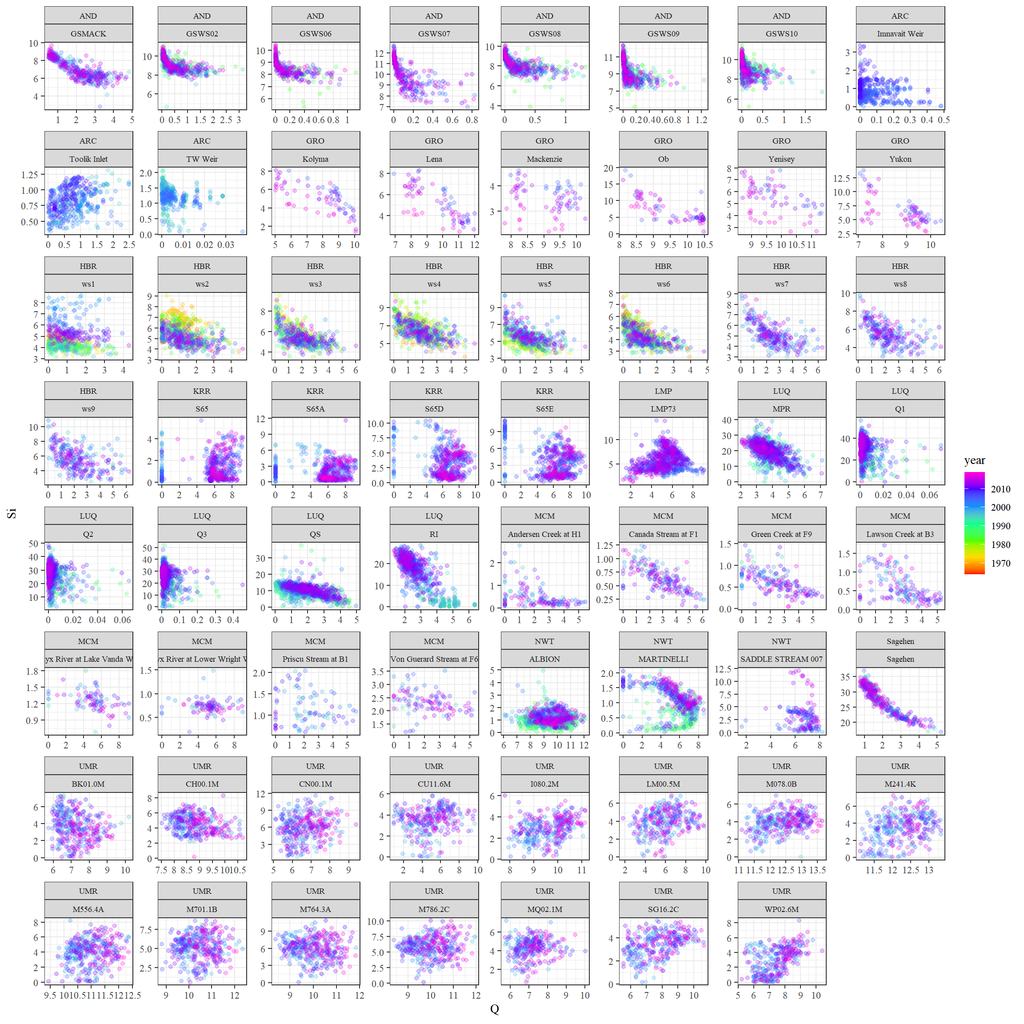

C-Q relationship of all sites with available data.

```r
site.vals=unique(dat$site.name)

CQ.rslt=data.frame()
for(i in 1:length(site.vals)){
  tmp=subset(dat,site.name==site.vals[i])
  tmp$logQ=log(tmp$Q+1)
  tmp$logC=log(tmp$Si)

  rslt=with(tmp,CQ_fun(logQ,logC,median(Q+1,na.rm=T),plot=F))
  rslt$SITE=site.vals[i]
  rslt$LTER=unique(tmp$LTER)
  CQ.rslt=rbind(CQ.rslt,rslt)
}

head(CQ.rslt,2L)
```

```
##          LL.R2    LL.R2.adj   LL.RMSE     LL.beta LL.beta.SE LL.beta.tval
## 1 0.0005475968 -0.000491335 0.5144224 -0.01141096 0.01571757   -0.7260005
## 2 0.1508349862  0.144681617 0.7198764 -0.20764344 0.04193954   -4.9510184
##   LL.beta.pval    LL.alpha    LL.AIC    LL.BIC LL.LogLik LL.assumpt.pass
## 1 4.680151e-01  0.08194892 1458.1495 1472.7628 -726.0747              No
## 2 2.120389e-06 -0.62016070  309.2592  318.0841 -151.6296             Yes
##    seg.bk.est seg.bk.SE      seg.R2    seg.R2.adj  seg.RMSE   seg.AIC   seg.BIC
## 1 62217.95768  1.521093 0.002792477 -0.0003237965 0.5143793 1459.9818 1484.3372
## 2     1.17013  1.165232 0.235717577  0.2188584058 0.6879532  298.5149  313.2231
##   seg.LogLik     Q50 moatar.beta.inf moatar.R2.inf moatar.R2.adj.inf
## 1  -724.9909 12810.0     -0.00047434  3.734076e-07      -0.002082959
## 2  -144.2574    10.9     -0.02867711  6.393908e-04      -0.014276439
##   moatar.RMSE.inf moatar.beta.sup moatar.R2.sup moatar.R2.adj.sup
## 1       0.4781620      0.03248396   0.001093619     -0.0009874362
## 2       0.8861889     -0.17356137   0.075104949      0.0613005449
##   moatar.RMSE.sup moatar.C_Q50                 SITE LTER
## 1       0.5485169    0.9618526               ALBION  NWT
## 2       0.4827239    0.3607766 Andersen Creek at H1  MCM
```

**Download `CQ.rslt` as Excel file**